# Reproducible Reseach: Class Project 1

Frederick Cabasa

July 2, 2017

## Introduction

It is now possible to collect a large amount of data about personal movement using activity monitoring devices such as a Fitbit, Nike Fuelband, or Jawbone Up. These type of devices are part of the “quantified self” movement – a group of enthusiasts who take measurements about themselves regularly to improve their health, to find patterns in their behavior, or because they are tech geeks. But these data remain under-utilized both because the raw data are hard to obtain and there is a lack of statistical methods and software for processing and interpreting the data.

## Overview

This assignment makes use of data from a personal activity monitoring device. This device collects data at 5 minute intervals through out the day. The data consists of two months of data from an anonymous individual collected during the months of October and November, 2012 and include the number of steps taken in 5 minute intervals each day.

The variables in the dataset are:

- steps: Number of steps taking in a 5-minute interval (missing values are coded as NA)
- date: The date on which the measurement was taken in YYYY-MM-DD format
- interval: Identifier for the 5-minute interval in which measurement was taken

#### 1. Code for reading in the dataset and/or processing the data

The following code sets up the working directory and creates the csv r object.

```r
library(knitr)
library(ggplot2)
library(dplyr)
temp <- tempfile()
download.file("https://d396qusza40orc.cloudfront.net/repdata%2Fdata%2Factivity.zip", temp, mode="wb")
unzip(temp,"activity.csv")
```

```r
activitydata <- read.csv("activity.csv", header=T)
activitydata$date <- as.Date(activitydata$date)
```

#### 2. Histogram of the total number of steps taken each day

Missing values were included to show magnitude of NA values in dataset. The total number of steps per day were calculated in the TotalStepsPerDay data frame.

```r
TotalStepsPerDay <- aggregate(activitydata$steps, list(date=activitydata$date), FUN = sum, na.rm=TRUE)
```

A histogram of the various total number of steps per day values was constructed to show the magnitude of total steps. The NA value was shown to show the number of times/days that no steps were recorded.

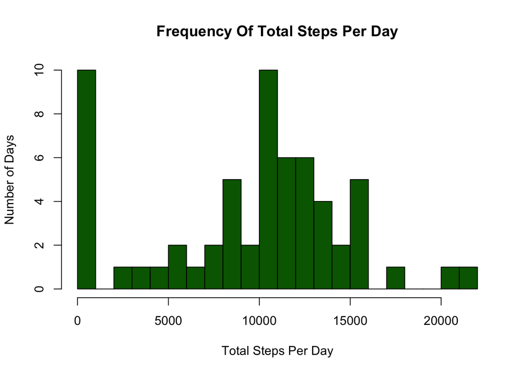

```r
hist(TotalStepsPerDay$x,
      main="Frequency Of Total Steps Per Day",
      xlab = "Total Steps Per Day",
      ylab = "Number of Days",
      col = "Dark Green",
      breaks = 25)
```

#### 3) Mean and median number of steps taken each day

```r
paste("Mean Steps per Day =", round(mean(TotalStepsPerDay$x, na.rm=TRUE),1))
```

```
## [1] "Mean Steps per Day = 9354.2"
```

```r
paste("Median Steps per Day =", round(median(TotalStepsPerDay$x, na.rm=TRUE),1))
```

```
## [1] "Median Steps per Day = 10395"
```

#### 4) Time series plot of the average number of steps taken

We will load the ggplot and plyr libraries to use the ggplot graph and dplyr functionality.

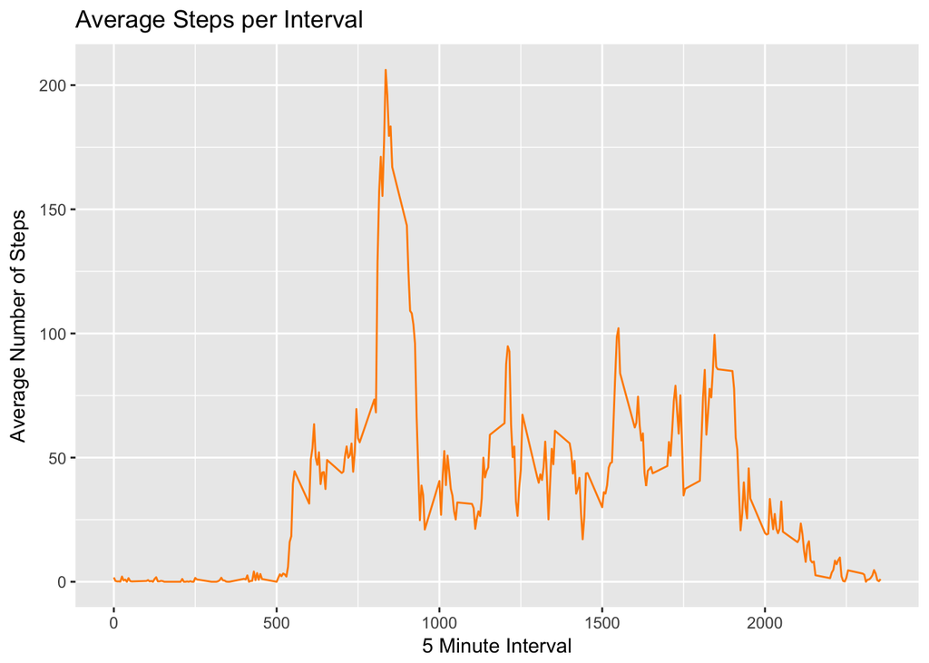

```r
library(ggplot2)
library(plyr)
AvgStepsPerInterval <- ddply(activitydata, "interval", summarize, avg=mean(steps,na.rm=TRUE))

ggplot(AvgStepsPerInterval, aes(x=interval, y = avg, group = 1))+
    labs(title="Average Steps per Interval")+
    labs(x="5 Minute Interval", y="Average Number of Steps")+
    geom_line(colour="Dark Orange")
```

#### 5) The 5-minute interval that, on average, contains the maximum number of steps

```r
MaxNumSteps <- AvgStepsPerInterval$interval[which.max(AvgStepsPerInterval$avg)]
paste("The Interval With The Maximum Value is", MaxNumSteps)
```

```
## [1] "The Interval With The Maximum Value is 835"
```

```r
MaxIntMean <- max(AvgStepsPerInterval$avg)
paste("The Maximum Interval Mean Steps is", round(MaxIntMean,1))
```

```
## [1] "The Maximum Interval Mean Steps is 206.2"
```

#### 6) Code to describe and show a strategy for imputing missing data

Missing Data Imputation Strategy:

1. Calculate the total number of missing values in proportion to the data set

```r
missing <- sum(is.na(activitydata))
n <- nrow(activitydata)
proportion <- round(missing/n*100, 1)
paste ("The total number of missing values is", missing, "which translates to", proportion, "% of the dataset.")
```

```
## [1] "The total number of missing values is 2304 which translates to 13.1 % of the dataset."
```

2. Create a new imputed dataset that replaces the missing values with the mean of the 5-minute interval

```r
activitydata.imputed <- ifelse(is.na(activitydata$steps), round(AvgStepsPerInterval$avg[match(activitydata$interval,
                        AvgStepsPerInterval$interval)],0), activitydata$steps)

activitydata2 <- data.frame(steps=activitydata.imputed, interval=activitydata$interval, date=activitydata$date)

TotalStepsPerDayImputed <- aggregate(activitydata2$steps, list(activitydata2$date), FUN=sum)
colnames(TotalStepsPerDayImputed)[1] <- c("date")
```

3. Recreate histogram and numbers using imputed dataset as in step 7:

#### 7) Histogram of the total number of steps taken each day after missing values are imputed

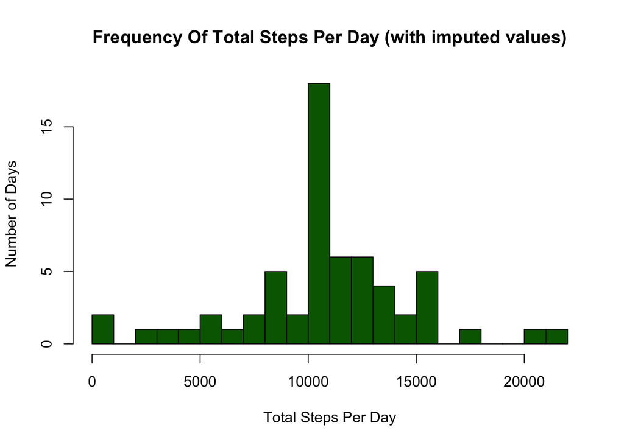

```r
hist(TotalStepsPerDayImputed$x,
     main="Frequency Of Total Steps Per Day (with imputed values)",
     xlab = "Total Steps Per Day",
     ylab = "Number of Days",
     col = "Dark Green",
     breaks = 25)
```

We definitely see a significant drop of the 0-1000 size bin with all of the NA values imputed with the average values per interval. Thus, we see an increase around the center of the histogram to account for the imputation strategy.

```r
paste("Mean Steps per Day =", round(mean(TotalStepsPerDayImputed$x, na.rm=TRUE),1))
```

```
## [1] "Mean Steps per Day = 10765.6"
```

```r
paste("Median Steps per Day =", round(median(TotalStepsPerDayImputed$x, na.rm=TRUE),1))
```

```
## [1] "Median Steps per Day = 10762"
```

#### 8) Panel plot comparing the average number of steps taken per 5-minute interval across weekdays and weekends

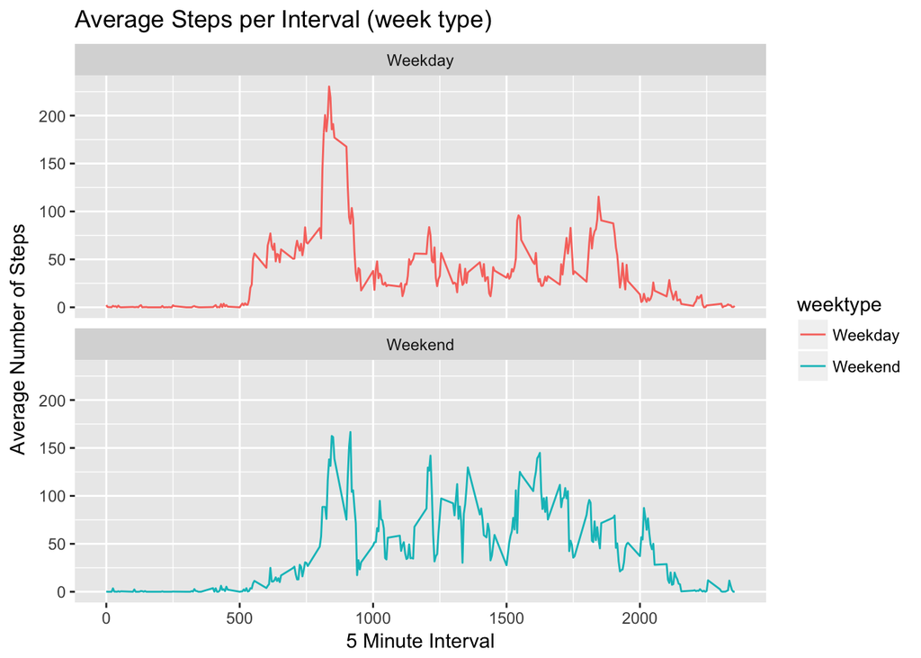

```r
weekdays <- c("Monday", "Tuesday", "Wednesday", "Thursday", "Friday")
activitydata2$weekday <- weekdays(activitydata2$date)
activitydata2$weektype <- as.factor(ifelse(is.element(weekdays(as.Date(activitydata2$date)), weekdays), "Weekday", "Weekend"))

AvgStepsPerIntervalWvW <- aggregate(steps~interval+weektype, data=activitydata2, FUN=mean, na.action=na.omit)
AvgStepsPerIntervalWvW$time <- AvgStepsPerInterval$interval/100

ggplot(AvgStepsPerIntervalWvW, aes(x=interval, y = steps, color=weektype))+
  labs(title="Average Steps per Interval (week type)")+
  labs(x="5 Minute Interval", y="Average Number of Steps")+
  geom_line()+facet_wrap( ~weektype, ncol=1, nrow=2)
```